# Final Project

Zhaobin Liu

5/4/2019

## Statistics and the Law

H0: Rate of white applicants are the same as minority applicant H1: Rate of white applicants are different

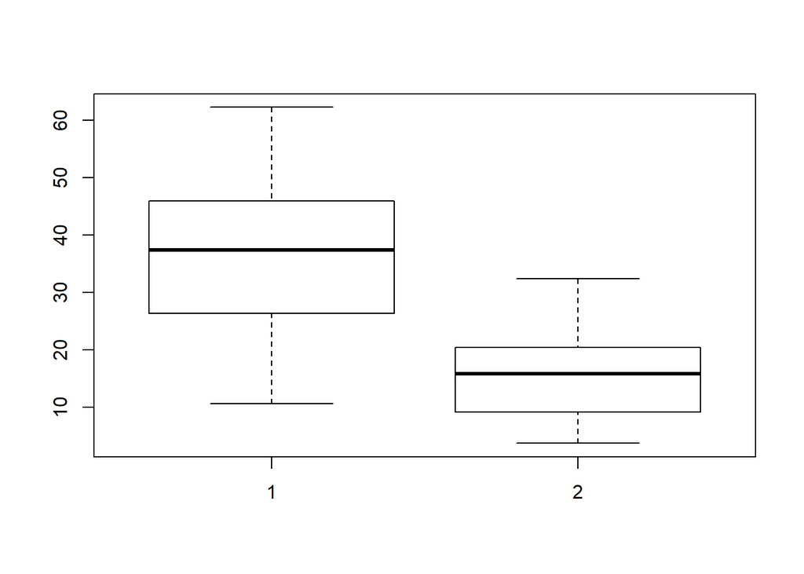

```r
acorn <-read.csv("acorn.csv")
boxplot(acorn$MIN,acorn$WHITE)
```

```r
ftest <- var.test(acorn$MIN,acorn$WHITE)
ftest
```

```
##
##  F test to compare two variances
##
## data:  acorn$MIN and acorn$WHITE
## F = 2.8026, num df = 19, denom df = 19, p-value = 0.02993
## alternative hypothesis: true ratio of variances is not equal to 1
## 95 percent confidence interval:
##  1.109297 7.080589
## sample estimates:
## ratio of variances
##           2.802583
```

We can see that the p-value of F-test is p = 0.02993. It is less than the significance level alpha which is 0.05. Thus, there is significant difference between the variances of the two sets of data. We can use t-test witch assume unequal variances.

```r
res <- t.test(acorn$MIN, acorn$WHITE, var.equal = FALSE,alternative = "greater")
res
```

```
##
##  Welch Two Sample t-test
##
## data:  acorn$MIN and acorn$WHITE
## t = 6.2533, df = 31.028, p-value = 2.979e-07
## alternative hypothesis: true difference in means is greater than 0
## 95 percent confidence interval:
##  15.49313      Inf
## sample estimates:
## mean of x mean of y
##   36.8815   15.6250
```

Conclusion:

The p-value of the test is 2.979e-07 that is less than the significance level alpha which is 0.05. We reject the null hypothesis and support the argument that the data are sufficient evidence of discrimination to warrant corrective action.

## Comparing suppliers

We will use chi-square test to conduct the analysis since the quality of ornithopters are categorical, instead of continuous variable

Ho: ornithopters made by all three schools produce same qualities Ha: ornithopters made by all three shcools produce different qualities

```r
table <- matrix(c(12,23,89,8,12,62,21,30,119),ncol=3,nrow = 3,byrow=TRUE)
colnames(table) <- c("Dead","Art","Fly")
rownames(table) <- c("Area51","BDV","Giffen")
table <- as.table(table)

chisq.test(table,correct = F)
```

```
##
##  Pearson's Chi-squared test
##
## data:  table
## X-squared = 1.3006, df = 4, p-value = 0.8613
```

Since the p-value is 0.8613 greater than 0.05, we fail to reject the null hypothesis. We conclude that ornithopters made by all three schools produce same qualities.

## How deadly are sharks

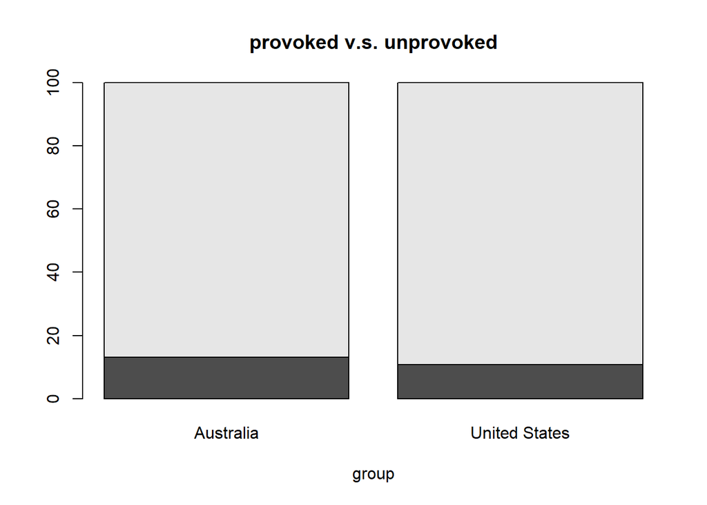

```r
shark <- read.csv("sharkattack.csv")
p <- shark%>%filter(Country.code=="US"|Country.code=="AU")%>%
  filter(Type=="Provoked"|Type=="Unprovoked")
p_table<-table(droplevels(p$Type),droplevels(p$Country))
coul = brewer.pal(3, "Pastel2")
data_percentage=apply(p_table, 2, function(x){x*100/sum(x,na.rm=T)})
barplot(data_percentage,xlab="group", main = "provoked v.s. unprovoked")
```

```r
fatal<-p<-shark%>%filter(Country.code=="US"|Country.code=="AU")%>%
  filter(Fatal=="Y"|Fatal=="N")
fatal<-table(droplevels(fatal$Country),droplevels(fatal$Fatal))

knitr::kable(fatal)
```

|  | N | Y |
| --- | --- | --- |
| Australia | 879 | 318 |
| United States | 1795 | 217 |

By looking at the fatal versus non-fatal sharks attacks in these two countrie, we can see that there are more sharks attacks in the United States. On the other hand, the proportion of fatal attacks in Australia (26.5%) is much higher than that in the United States (10%). To further test whether Sharks Australia are more deadly or fatal than those in the United States, we will conduct the chi-square test.

```r
chisq.test(fatal,correct = F)
```

```
##
##  Pearson's Chi-squared test
##
## data:  fatal
## X-squared = 134.54, df = 1, p-value < 2.2e-16
```

```r
prob <- matrix(c(0.2739171,0.5593643,0.09909629,0.06762231), nrow=2,
               dimnames = list(c("Australi","US"),c("NonFatal","Fatal")))
prob
```

```
##           NonFatal      Fatal
## Australi 0.2739171 0.09909629
## US       0.5593643 0.06762231
```

```r
total<-879+318+1795+217
pwr.chisq.test(w = ES.w2(prob), N = total, df = 1, sig.level = 0.05)
```

```
##
##      Chi squared power calculation
##
##               w = 0.2047583
##               N = 3209
##              df = 1
##       sig.level = 0.05
##           power = 1
##
## NOTE: N is the number of observations
```

From the chi-square test, we have sufficient evidence to say that that sharks attacks in Australia is more fatal than that of in the United States even though the number of attacks in the United States is higher than that of Australia. With sample size equal to 3209, the statistical power of the test chi-square test is 1.

## Power Analysis

The arcsine transformation is calculated by two times the arcsine of the square root of the proportion.We can transform the proportional parameter from (0,1) to (−π/2,π/2). The effect of the arcsine transformation is similar to the logit. It pulls out the ends of the distribution except the extent that the logit does.

The power to detect the hypothetical parameters are 0.65 and 0.45 is 0.48 while the power to detect the difference between hypothetical parameters 0.25 and 0.05 is 0.82, even though the difference between both pairs of values is 0.2. The reason is that 0.25 and 0.05 are at the end which is extreme value of the distribution. Therefore, it takes more power to detect and arcsine transformation can solve this problem

# Case1 MLE of Exponential Distribution

$$f(x;\lambda)=\lambda e^{-\lambda x}$$

$$L(\lambda;X_1,...,X_n)=\lambda e^{-\lambda X_1}\lambda e^{-\lambda X_2}...\lambda e^{-\lambda X_n}$$

$$L(\lambda;X_1,...,X_n)=\lambda^ne^{-\lambda\sum X_i}$$

$$l(\lambda;X_1,...,X_n)=nlog(\lambda)-\lambda \sum X_i$$

$$\frac{dl(\lambda;X1,...,Xn)}{d\lambda}=\frac{n}{\lambda}-\sum X=0$$

$$\hat\lambda=\frac{n}{\sum X_i}=\frac{1}{\bar X_n}$$

# Case2 Moment Estimator and MLE for new distribution $\theta$

MOM:

$$\begin{align}
E[X]\ & =\ \int^1_0 x((1-\theta)\ +\ 2\theta x)dx \notag \\
& =\ (1-\theta)\int^1_0 xdx +\ \int^1_0 2\theta x^2 dx \notag \\
& =\ (1-\theta)\frac{1}{2}x^2\arrowvert^1_0\ +\ 2\theta \frac{1}{3}x^3\arrowvert^1_0\ \notag \\
& =\ \frac{1}{2} -\ \frac{1}{2}\theta\ +\ \frac{2}{3}\theta \notag \\
& =\ \frac{1}{6}\theta+\frac{1}{2} \notag
\end{align}$$

MLE:
$$L(\theta;X_1,...,X_n)=[(1-\theta)+2\theta X_1]...[(1-\theta)+2\theta X_n]$$

$$l(\theta;X_1,...,X_n)=log[(1-\theta)+2\theta X_1]+...+log[(1-\theta)+2\theta X_1]$$
In this situation, we cannot taking the derivative of $l(\theta;X_1,...,X_n)$ to find the maximum value with corresponding $\theta$.

## Rain in Southern Illinois

```r
ill.60 <- read.table("D:/ma677/677final/ill-60.txt", quote="\"", comment.char="")
yr60<-as.numeric(as.array(ill.60[,1]))
ill.61 <- read.table("D:/ma677/677final/ill-61.txt", quote="\"", comment.char="")
yr61<-as.numeric(as.array(ill.61[,1]))
ill.62 <- read.table("D:/ma677/677final/ill-62.txt", quote="\"", comment.char="")
yr62<-as.numeric(as.array(ill.62[,1]))
ill.63 <- read.table("D:/ma677/677final/ill-63.txt", quote="\"", comment.char="")
yr63<-as.numeric(as.array(ill.63[,1]))
ill.64 <- read.table("D:/ma677/677final/ill-64.txt", quote="\"", comment.char="")
yr64<-as.numeric(as.array(ill.64[,1]))
```

```r
library(fitdistrplus)
```

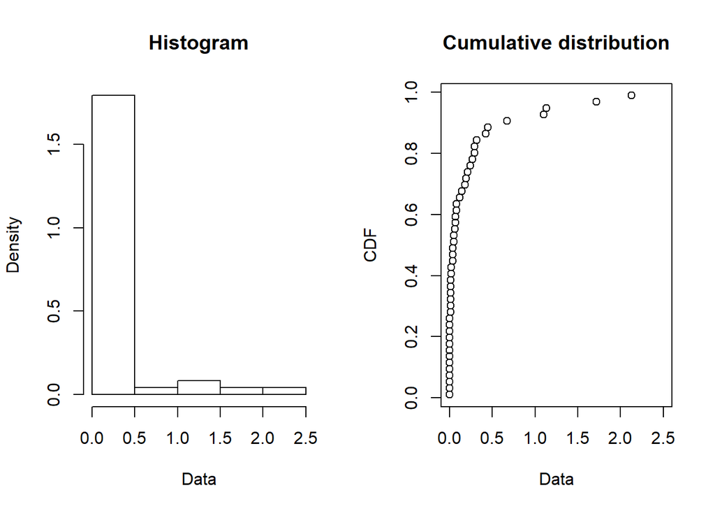

```r
plotdist(yr60)
```

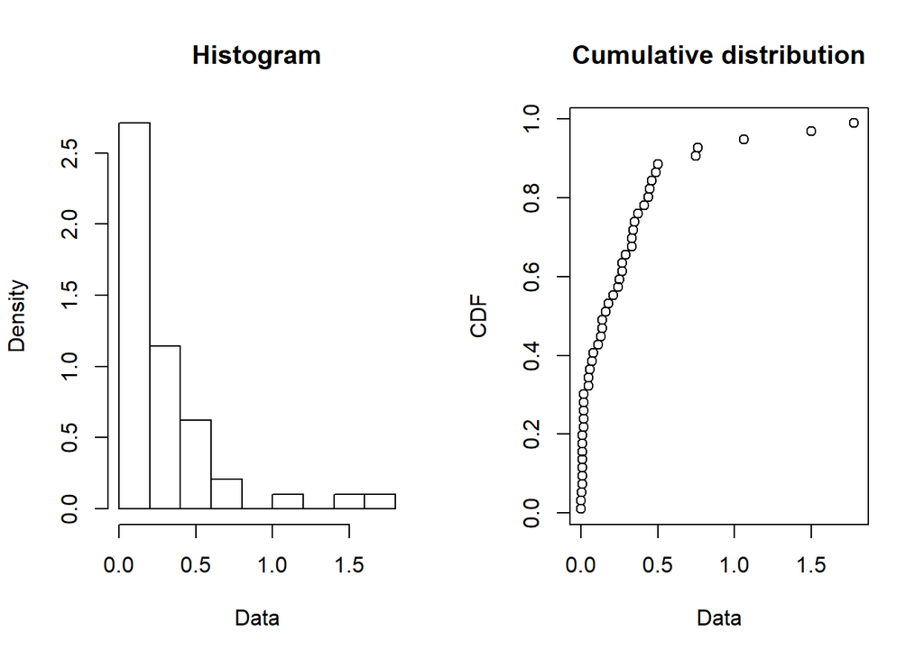

```r
plotdist(yr61)
```

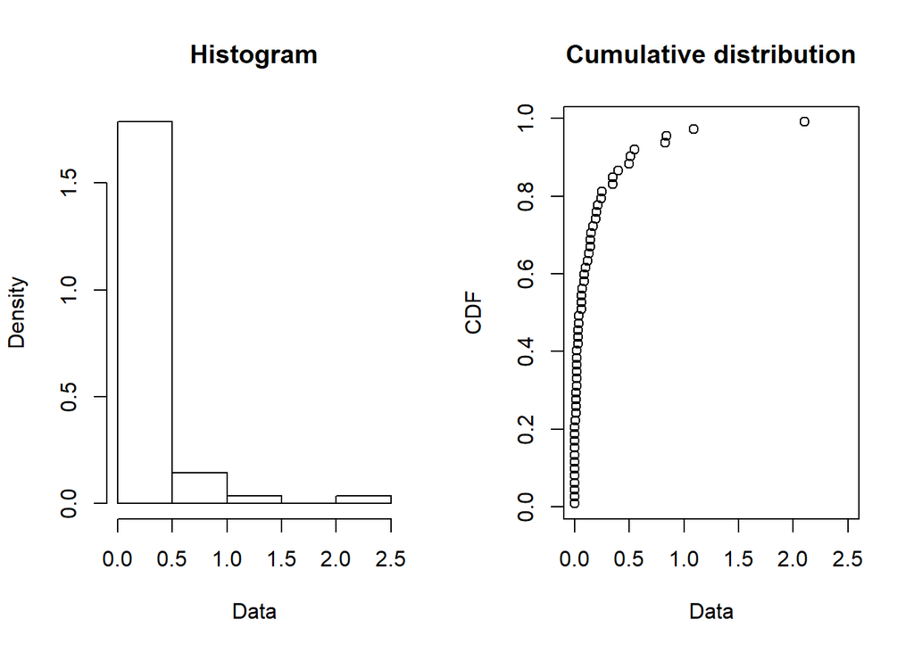

```r
plotdist(yr62)
```

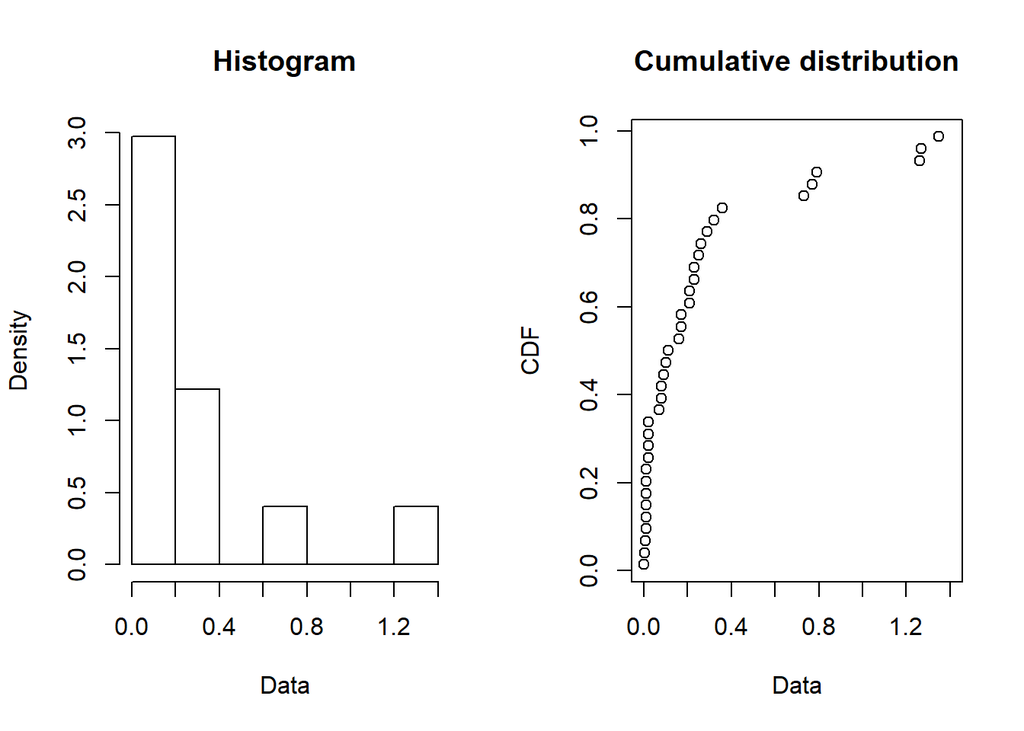

```r
plotdist(yr63)
```

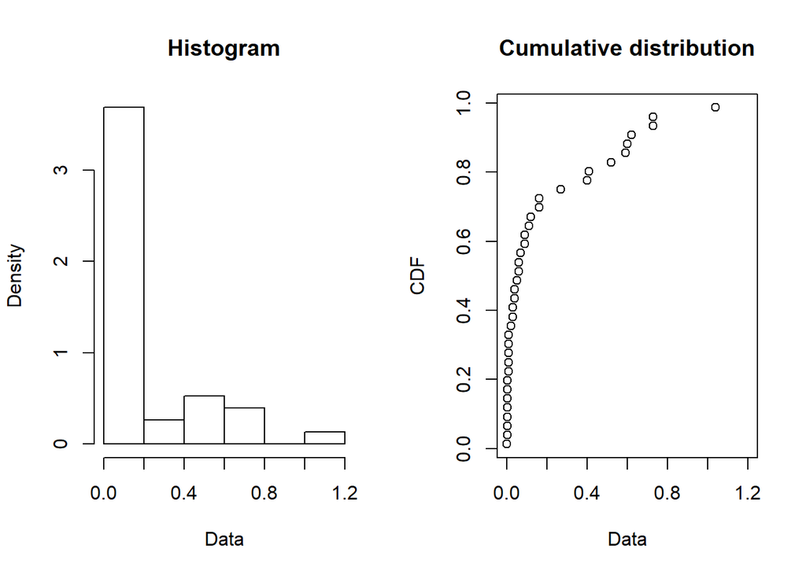

```r
plotdist(yr64)
```

From the distribution we can get that: the total rainfall for 1960 is 10.574.The total rainfall for 1961 is 13.197.The total rainfall for 1962 is 10.346. The total rainfall for 1963 is 9.71.The total rainfall for 1960 is 7.11.

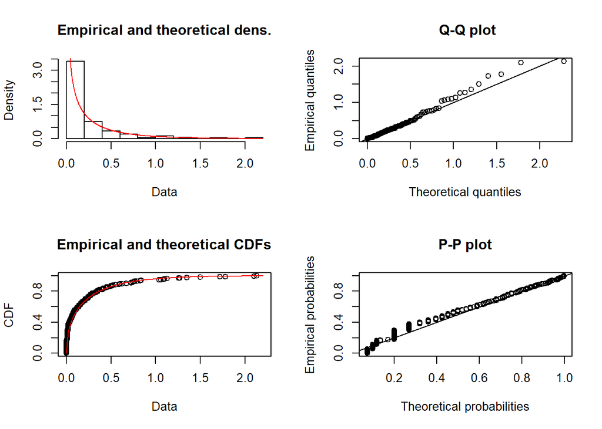

```r
all_rainfall<-c(yr60,yr61,yr62,yr63,yr64)


gamma <- fitdist(all_rainfall, "gamma")
plot(gamma)
```

```r
summary(gamma)
```

```
## Fitting of the distribution ' gamma ' by maximum likelihood
## Parameters :
##        estimate Std. Error
## shape 0.4408386  0.0337663
## rate  1.9648409  0.2474440
## Loglikelihood:  185.3477   AIC:  -366.6954   BIC:  -359.8455
## Correlation matrix:
##           shape      rate
## shape 1.0000000 0.6082109
## rate  0.6082109 1.0000000
```

We fit the gamma distribution into all observed rainfall data of year between 1960 and 1964. From the density and QQplots, the gamma distribution fits really well on this data. The authors are right to use gamma distribution.

```r
f <- fitdist(all_rainfall, "gamma",method = "mme")
b <- bootdist(f)
summary(b)
```

```
## Parametric bootstrap medians and 95% percentile CI
##          Median      2.5%     97.5%
## shape 0.3970219 0.2758162 0.5318888
## rate  1.7702009 1.1578002 2.5588069
```

```r
fgamma <- fitdist(all_rainfall, "gamma",method = "mle")
bgmm <- bootdist(fgamma)
summary(bgmm)
```

```
## Parametric bootstrap medians and 95% percentile CI
##          Median      2.5%     97.5%
## shape 0.4430484 0.3805821 0.5160222
## rate  1.9777792 1.5786669 2.5320409
```

## Decision Theory

$$P(x_1,...,x_n|\delta)=\prod_{i=1}^{N}P(X=x_i|\delta)=\prod_{i=1}^{N}\delta^{x_i}(1-\delta)^{x_i}$$
Let n be number of $\beta$ with value 1
$$(\beta_s, s\in S)=(0,1)$$
$$P(x_1,...,x_n|\delta)=\delta^{n}(1-\delta)^{N-n}$$
Prior:
$$P(\delta)=Beta(c,d)=\frac{1}{B(c,d)}\delta^{c-1}(1-\delta)^{d-1}$$
From Bayes
$$P(\delta|x_1,...,x_n)=P(x_1,...,x_n|\delta)P(\delta)=\frac{1}{C}\delta^{c+n-1}(1-\delta)^{N-n+d-1}$$
Where $C=\int P(x_1,...,x_n,\delta)d\delta$ is the normalizing constant. But notice that this posterior is also a Beta distribution, with new parameters:
$$\delta|x_1,...,x_n \sim Beta(c+n, d+N-n)$$
$$\beta=E(\delta|x_1,...,x_n)=\frac{c+n}{c+d+N}$$
From:
$$\delta(n)=0\quad for \quad\beta<\alpha$$
$$\delta(n)=\lambda\quad for \quad\beta=\alpha, \quad where \quad 0<\lambda<1$$
$$\delta(n)=1\quad for \quad\beta>\alpha$$
We have:
$$\delta(n)=0\quad for \quad(c+n)/(c+d+N)<\alpha$$
$$\delta(n)=\lambda\quad for \quad(c+n)/(c+d+N)=\alpha, \quad where \quad 0<\lambda<1$$
$$\delta(n)=1\quad for \quad(c+n)/(c+d+N)>\alpha$$